# ST5226 Spatial Statistics Notes - Geostatistics and Spatial Predictions

Yeo Ming Jie, Jonathan (A0164616A)

## Lecture 7: Introduction to Geostatistics

Loading required packages:

```r
library(sp)
library(gstat)
library(rgdal)
library(RColorBrewer)
library(classInt)
```

### Meuse Dataset

Recall the Meuse river bank dataset which contained measurements of the metal concentration along the Meuse river in the Netherlands.

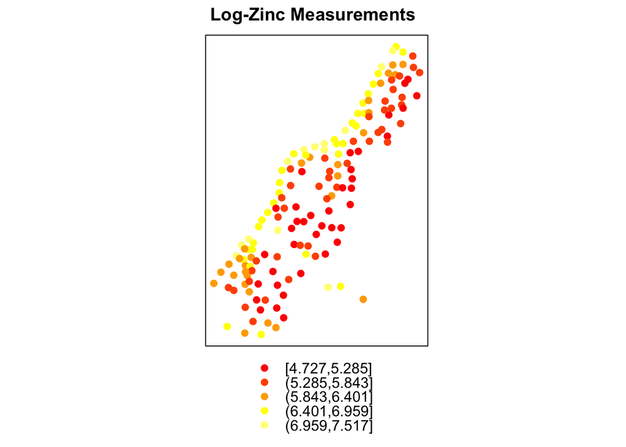

```r
data(meuse)
coordinates(meuse) <- ~x+y # converts meuse into SpatialPointsDataFrame
meuse$lzn <- log(meuse$zinc)
spplot(meuse, "lzn", main="Log-Zinc Measurements",
       col.regions = heat.colors(5))
```

Observe that the zinc concentrations is larger close to the river bank, clear spatial trend in a given direction - zinc concentrations decreasing as we move in a direction perpendicular to the river bank.

### Exploratory Variogram Analysis

Checking for existence/strength of spatial correlation from scatter plots of pairs $Z(s_i)$ and $Z(s_j)$ grouped according to their separation distances $h = ||s_i-s_j||$, i.e. h-scatter plots. Consider the plots for the following sets of distance bins:

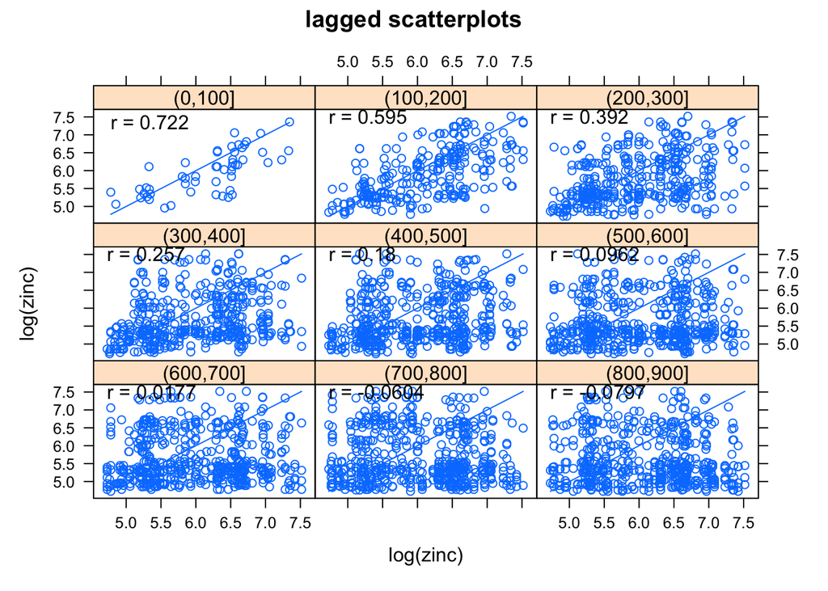

```r
hscat(log(zinc) ~ 1, meuse, (0:9)*100)
```

Plots indicate the correlation coefficient $r$, observe correlation decays with increasing distance.

Next, we plot the sample semivariogram estimator for meuse. Observe the following key features, e.g. nugget, sill $\approx 0.6$, Range $\approx 800$.

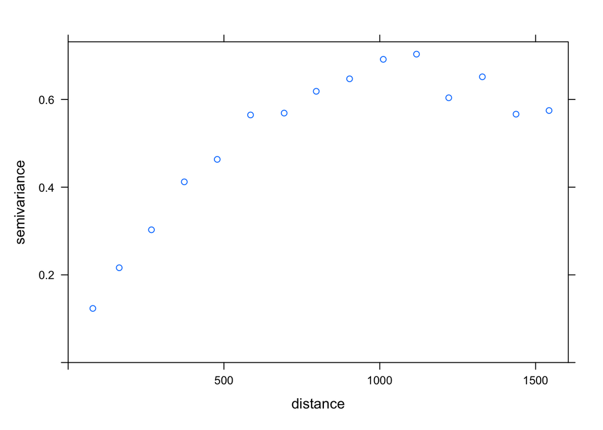

```r
vgm_log_zinc <- variogram(log(zinc) ~ 1, meuse) # Default in the North-South direction
# ~ 1 defines a single constant predictor, leading to a spatially constant mean coefficient
plot(vgm_log_zinc)
```

We can also investigate anisotropy i.e. the covariance function $C(\cdot)$ of the process is a function of both distance and direction, by computing the sample variogram in 4 different directions.

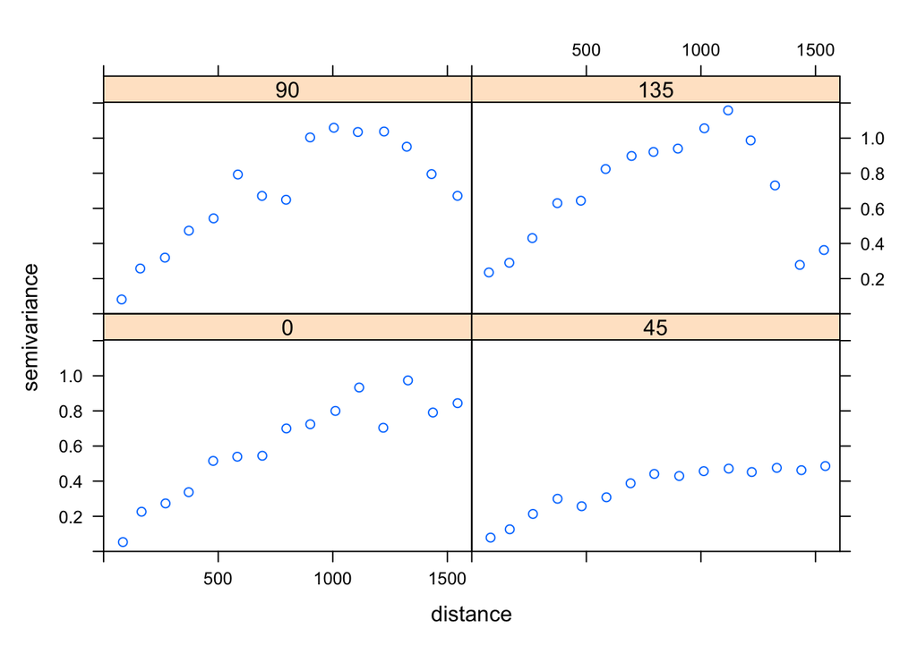

```r
# alpha vector of angles in degrees, clockwise from North
plot(variogram(log(zinc) ~ 1, meuse, alpha=c(0, 45, 90, 135)))
```

Observe that the variogram grows slowly in the NE direction, but grows most rapidly in the SE direction.

### Smoky Mountains Dataset (pH measurements)

Next, consider the dataset containing the pH measurements at locations within the Great Smoky Mountains. Observe from the plot that observations with high pH values lay around the boundary of the region.

```r
smoky_data <- read.table("/Users/jyeo_/Desktop/MSc Statistics Coursework/ST5226 Spatial Statistics/Data/smoky/smoky.dat", header=TRUE, skip=1)
coordinates(smoky_data) <- ~easting + northing # initialize Spatial Points Data Frame
smok <- readOGR("smoky", "smokypoly") # Spatial Polygons
```

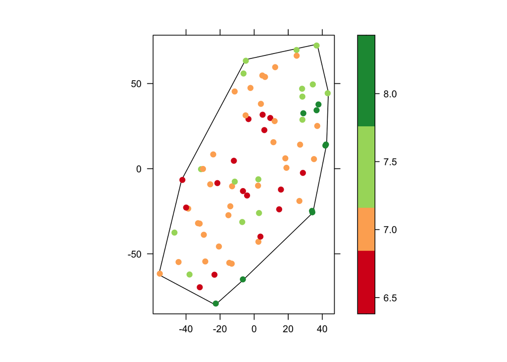

```r
pal <- brewer.pal(4, "RdYlGn")
q4 <- classIntervals(smoky_data$ph, n=4, style="fisher")
spplot(smoky_data, "ph", cuts=q4$brks , col.regions=pal, colorkey=TRUE,
       sp.layout=list("sp.polygons", smok), scales=list(draw=TRUE))
```

Note that the variogram object contains information on the exact values of $h$ used, along with the nuymber of points used to compute the estimate. Plotting the sample variogram estimator, we obtain the following:

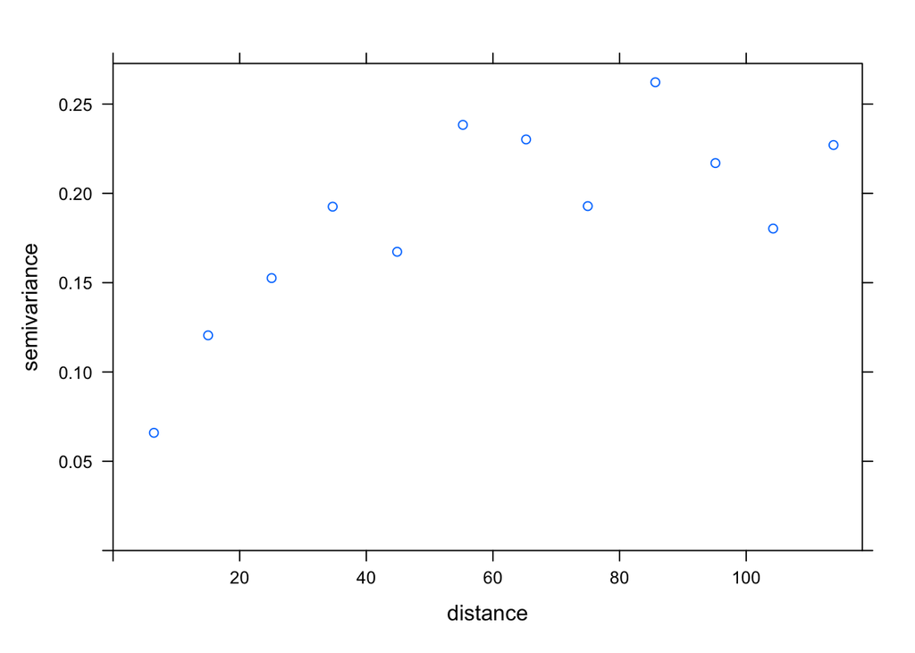

```r
vgm_ph <- variogram(ph ~ 1, smoky_data, cutoff=120, width=10)
head(vgm_ph, n=2)
##    np      dist      gamma dir.hor dir.ver   id
## 1  54  6.453213 0.06594352       0       0 var1
## 2 213 15.010015 0.12051268       0       0 var1
plot(vgm_ph)
```

### Available Semivariogram Types

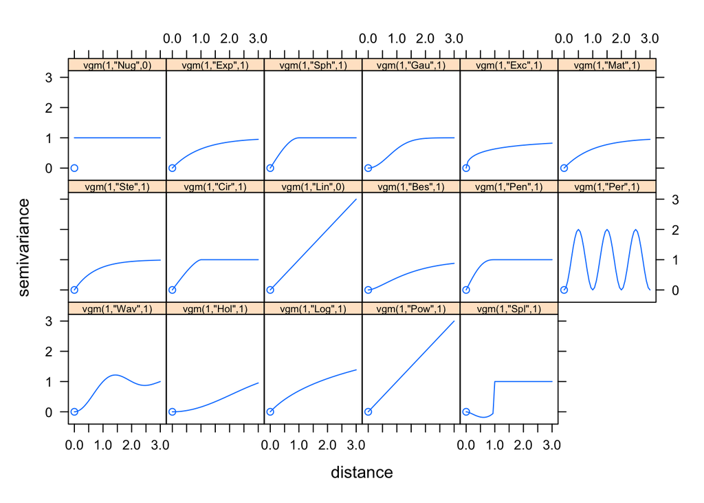

```r
show.vgms(par.strip.text=list(cex=0.6))
```

In order to get a full list of variogram names used in `gstat`, we can type `vgm()`. The `vgm()` function is used to generate variogram models (or add to existing models).

```r
head(vgm())
```

```
##   short                               long
## 1   Nug                       Nug (nugget)
## 2   Exp                  Exp (exponential)
## 3   Sph                    Sph (spherical)
## 4   Gau                     Gau (gaussian)
## 5   Exc Exclass (Exponential class/stable)
## 6   Mat                       Mat (Matern)
```

### Parametric Semivariograms

Suppose we wish to create a Spherical variogram with parameters $c_0=1$ (nugget), $c_s=2$ (partial sill) and $a_s = 10$ (range).

```r
sph1 <- vgm(psill=2, model='Sph', range=10, nugget=1)
class(sph1); sph1
```

```
## [1] "variogramModel" "data.frame"
```

```
##   model psill range
## 1   Nug     1     0
## 2   Sph     2    10
```

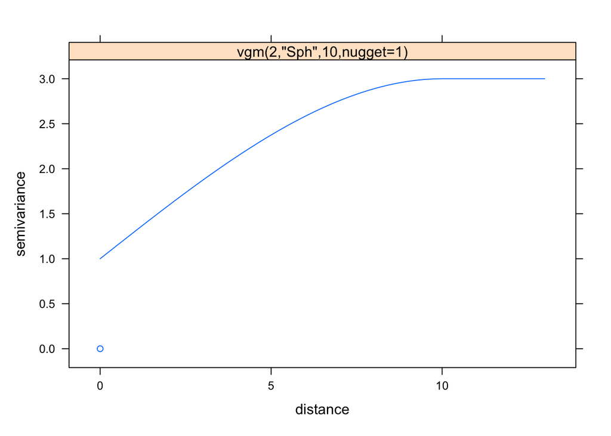

```r
# Plot of a particular semivariogram (Spherical)
show.vgms(sill=2, range=10, models='Sph', nugget=1, max=13)
```

Alternatively, consider the Gaussian semivariogram model with effective range $3a_e = 10$

```r
gauss1 <- vgm(psill=2, model='Gau', range=10, nugget=1)
gauss1
```

```
##   model psill range
## 1   Nug     1     0
## 2   Gau     2    10
```

### Adding Semivariograms

The sum of two valid semivariograms is also a valid semivariogram. Consider the addition of the Spherical and Gaussian semivariograms.

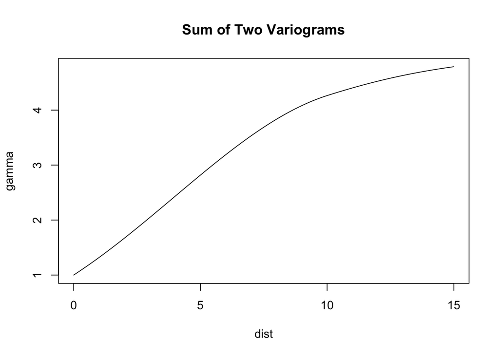

```r
gauss2 <- vgm(psill=2, model='Gau', range=10, nugget=0, add.to=sph1)
out <- variogramLine(gauss2, maxdist=15)
plot(out, type='l', main="Sum of Two Variograms")
```

```r
fit_v <- fit.variogram(vgm_log_zinc, vgm(1, "Sph", 800, 1))
fit_v
```

```
##   model      psill    range
## 1   Nug 0.05065923   0.0000
## 2   Sph 0.59060463 896.9976
```

```r
attr(fit_v, "SSErr")
```

```
## [1] 9.011194e-06
```

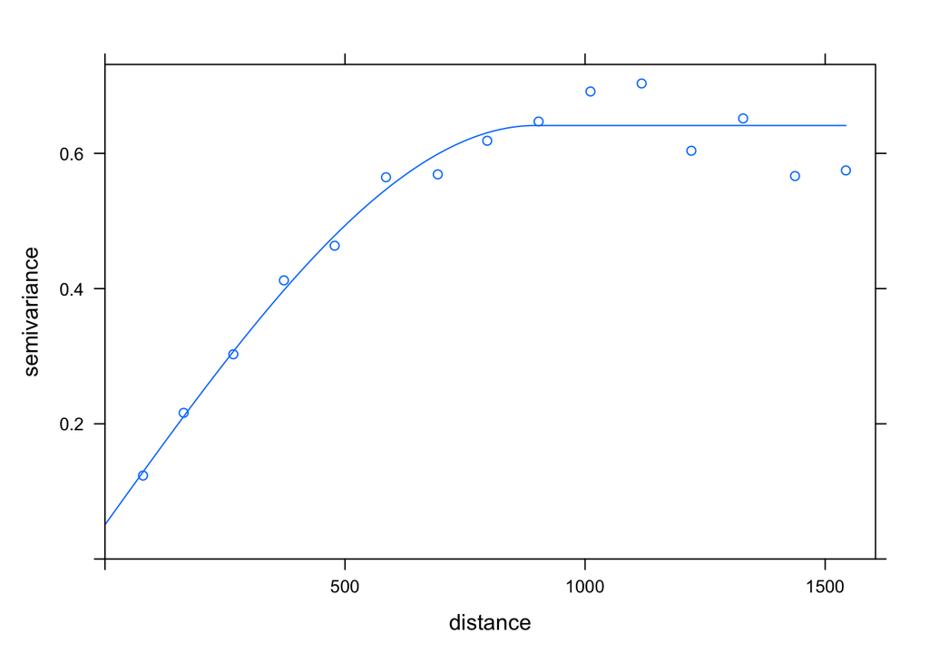

```r
plot(vgm_log_zinc, model=fit_v)
```

## Lecture 8: Spatial Prediction (Kriging)

```r
data(meuse.grid)
coordinates(meuse.grid) <- ~x+y
meuse.grid <- as(meuse.grid, "SpatialPixelsDataFrame")

idw.out <- gstat::idw(log(zinc) ~ 1, meuse, meuse.grid, idp=2.5)
```

```
## [inverse distance weighted interpolation]
```

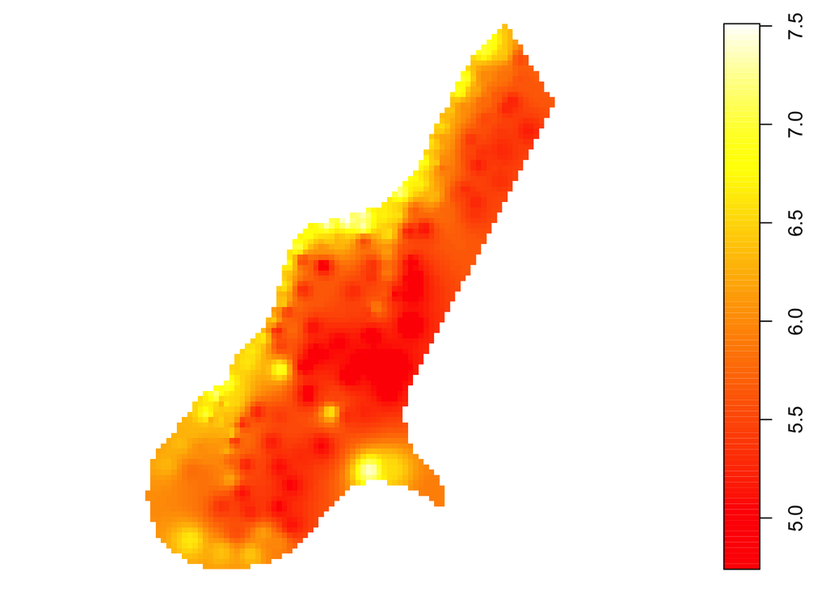

```r
plot(idw.out, col=heat.colors(100))
```

```r
head(as.data.frame(idw.out), n=2)
```

```
##        x      y var1.pred var1.var
## 1 181180 333740  6.390860       NA
## 2 181140 333700  6.561591       NA
```

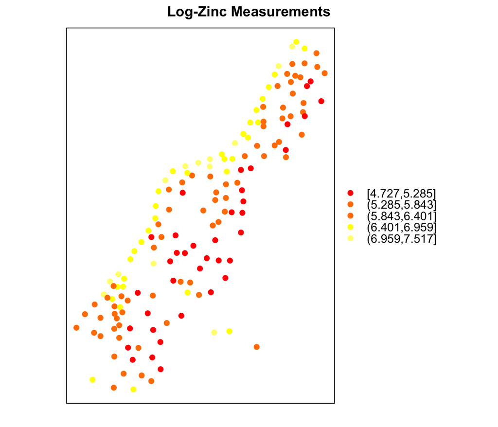

```r
spplot(meuse, "lzn", main="Log-Zinc Measurements",
       col.regions = heat.colors(4),key.space="right")
```

```r
vgm_log_zinc <- variogram(log(zinc) ~ 1, meuse)
fit_v <- fit.variogram(vgm_log_zinc, vgm(1, "Sph", 800, 1))
lz.ok <- krige(log(zinc)~1, meuse, meuse.grid, fit_v)
```

```
## [using ordinary kriging]
```

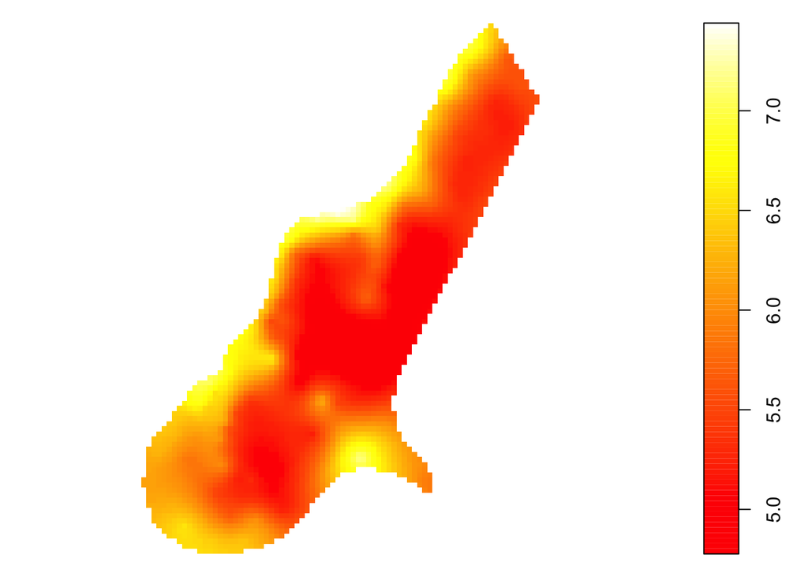

```r
plot(lz.ok, col=heat.colors(100))
```

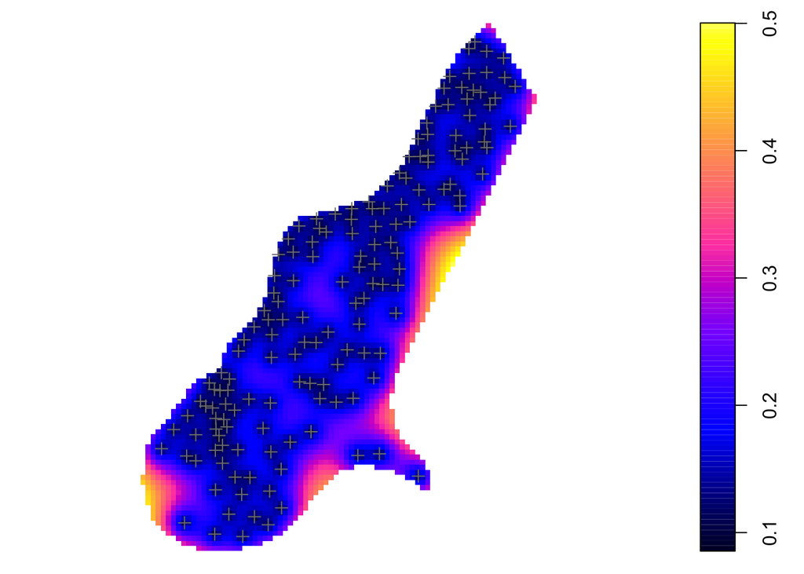

```r
plot(lz.ok['var1.var'])
plot(meuse, add=TRUE, col='grey50')
```

```r
err.fit <- fit.variogram(vgm_log_zinc, vgm(1, "Sph", 800, Err=1))
krige(log(zinc) ~ 1, meuse, meuse[1,], err.fit)
```

```
## [using ordinary kriging]
```

```
##        coordinates var1.pred   var1.var
## 1 (181072, 333611)  6.884405 0.03648707
```

```r
krige(log(zinc) ~ 1, meuse, meuse[1,], fit_v)
```

```
## [using ordinary kriging]
```

```
##        coordinates var1.pred     var1.var
## 1 (181072, 333611)  6.929517 4.907917e-34
```

```r
vt.fit2 <- fit.variogram.gls(log(zinc) ~ sqrt(dist), data=meuse[1:40,],
                             model= vgm(1, "Exp", 300, 1) ,trace=FALSE)
lz.uk.gls <- krige(log(zinc)~sqrt(dist), meuse, meuse.grid, vt.fit2)
```

```
## [using universal kriging]
```

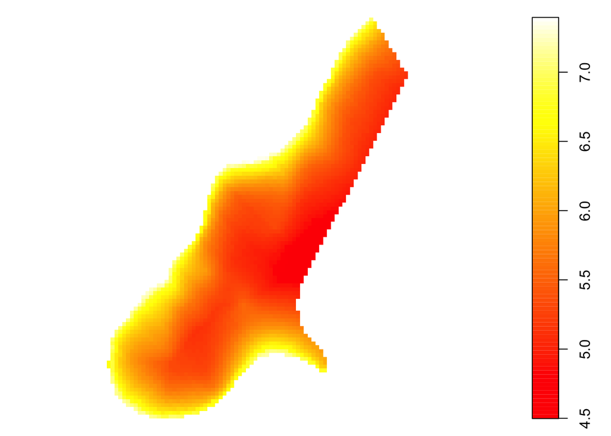

```r
plot(lz.uk.gls, col=heat.colors(100))
```